# activity_1: key

Christopher Loan

February 20, 2023

# Section 0: Set seed

Set a seed at `022023`

```r
set.seed(022023)
```

# Section 1: Fit Decision Tree to `ptitanic` Dataset

## Section 1.1: load packages

Load 6 packages:

1. `tidyverse`
2. `rsample`
3. `rpart`
4. `rpart.plot`
5. `vip`
6. `pdp`

If you did not install these already, you’ll have to install each of these with the `install.packages()` function. e.g., `install.packages('tidyverse')` etc.

```r
# data manipulation
library(tidyverse)
# setting up data: training / testing
library(rsample)
# decision trees
library(rpart)
# plotting decision trees
library(rpart.plot)
# variable importance plots
library(vip)
# partial dependency plots
library(pdp)
```

## Section 1.2: set up data

load the `ptitanic` data from the `rpart.plot` package.

```r
data(ptitanic)
```

Use `relevel()` to ensure `died` is the reference group in the `ptitanic` dataset.

```r
ptitanic <-
  ptitanic %>%
  mutate(
    survived = relevel(survived, ref = 'died')
  )
```

Use `rsample` to split the data into training and testing sets.

```r
split_data <- initial_split(ptitanic)
training_data <- training(split_data)
testing_data <- testing(split_data)
```

## Section 1.3: Fit a Decision Tree

Predict `survived` with all other variables in the dataset

**Hint:** there are 2 ways to include all variables: * One is simply listing all of them, separated with `+` symbols. * The other is a shortcut where you list the outcome, a tilde, then a period (`.`): `outcome_name ~ .`

```r
all_var_DT <-
  rpart(
    survived ~ .,
    data = training_data
    )
```

## Section 1.4: Explore Tree Structure

### Section 1.4.1: Look at the structure

#### Section 1.4.1a

print the tree object by just running the variable name

```r
all_var_DT
```

```
## n= 981
##
## node), split, n, loss, yval, (yprob)
##       * denotes terminal node
##
##   1) root 981 368 died (0.62487258 0.37512742)
##     2) sex=male 640 112 died (0.82500000 0.17500000)
##       4) age>=8.5 615  96 died (0.84390244 0.15609756) *
##       5) age< 8.5 25   9 survived (0.36000000 0.64000000)
##        10) pclass=3rd 14   5 died (0.64285714 0.35714286) *
##        11) pclass=1st,2nd 11   0 survived (0.00000000 1.00000000) *
##     3) sex=female 341  85 survived (0.24926686 0.75073314)
##       6) pclass=3rd 150  72 survived (0.48000000 0.52000000)
##        12) sibsp>=2.5 13   2 died (0.84615385 0.15384615) *
##        13) sibsp< 2.5 137  61 survived (0.44525547 0.55474453)
##          26) age>=19.5 104  52 died (0.50000000 0.50000000)
##            52) age< 21.5 7   1 died (0.85714286 0.14285714) *
##            53) age>=21.5 97  46 survived (0.47422680 0.52577320)
##             106) age>=27.5 45  19 died (0.57777778 0.42222222) *
##             107) age< 27.5 52  20 survived (0.38461538 0.61538462) *
##          27) age< 19.5 33   9 survived (0.27272727 0.72727273) *
##       7) pclass=1st,2nd 191  13 survived (0.06806283 0.93193717) *
```

#### Section 1.4.1b

Use `rpart.plot()` to view the structure of decision the tree in a cleaner format.

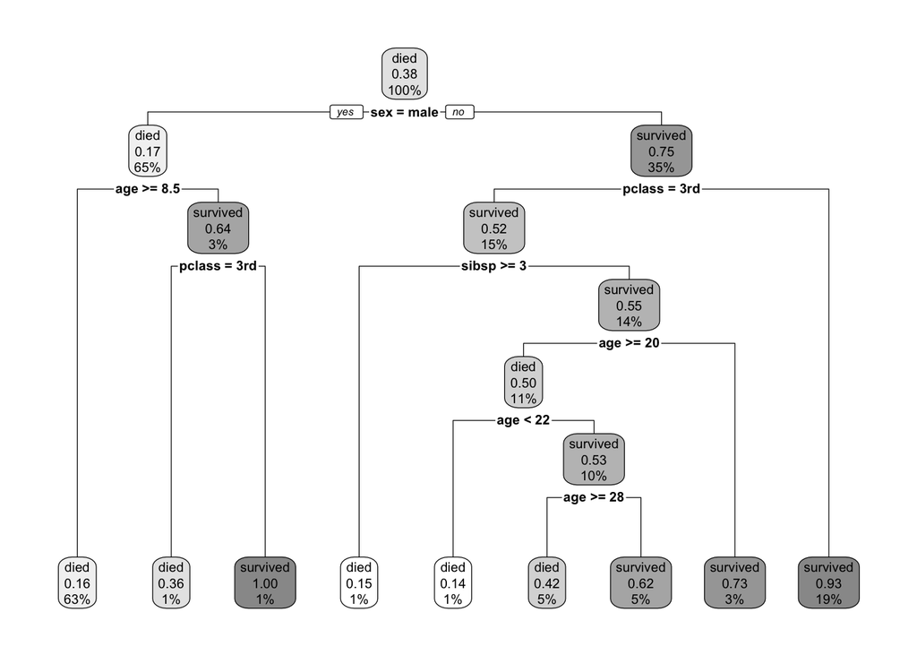

```r
rpart.plot(
  all_var_DT,
  box.palette = 'Grays'
  )
```

#### Section 1.4.2

Use `vip()` to visualize the variable importance plot for the decision tree.

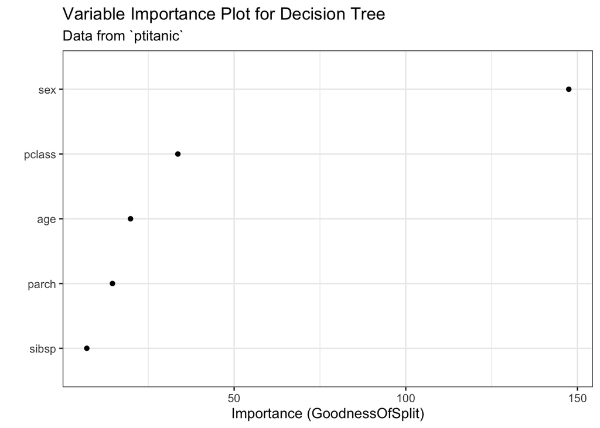

```r
vip(
  all_var_DT,
  geom = 'point',
  include_type = TRUE
) +
  theme_bw(base_size = 12) +
  labs(
    title = 'Variable Importance Plot for Decision Tree',
    subtitle = 'Data from `ptitanic`',
  )
```

#### Section 1.4.3

Use `pdp` to visualize bivariate (i.e., with 2 variables) partial dependency plots (PDPs) with pairs (i.e., 2) of the top 3 variables. Bivariate pairs of V1, V2, and V3, for example, are: * V1 & V2 * V1 & V3 * V2 & V3

**tip:** use `plot = TRUE` in your PDP, instead of using `ggplot2`, unless you feel comfortable with `ggplot2`.

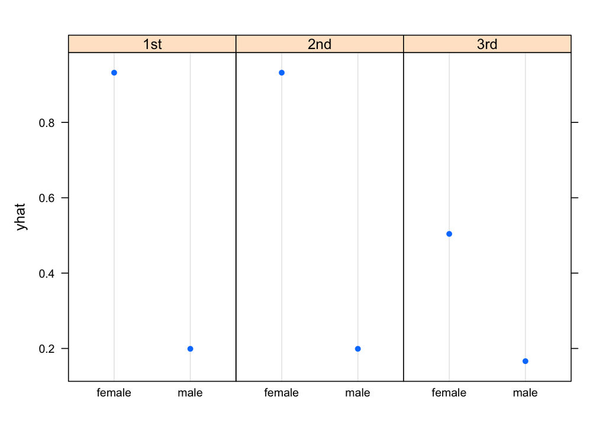

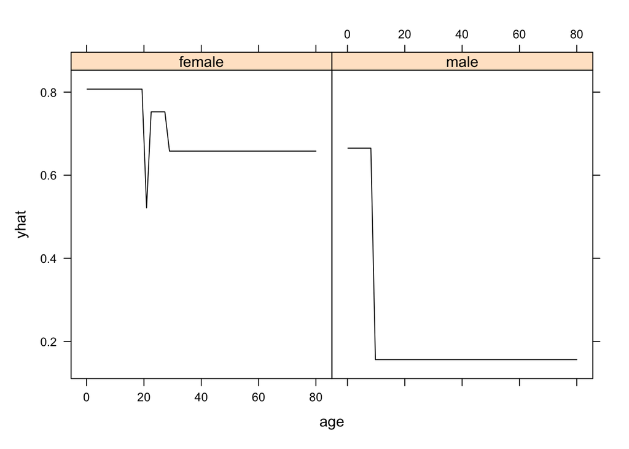

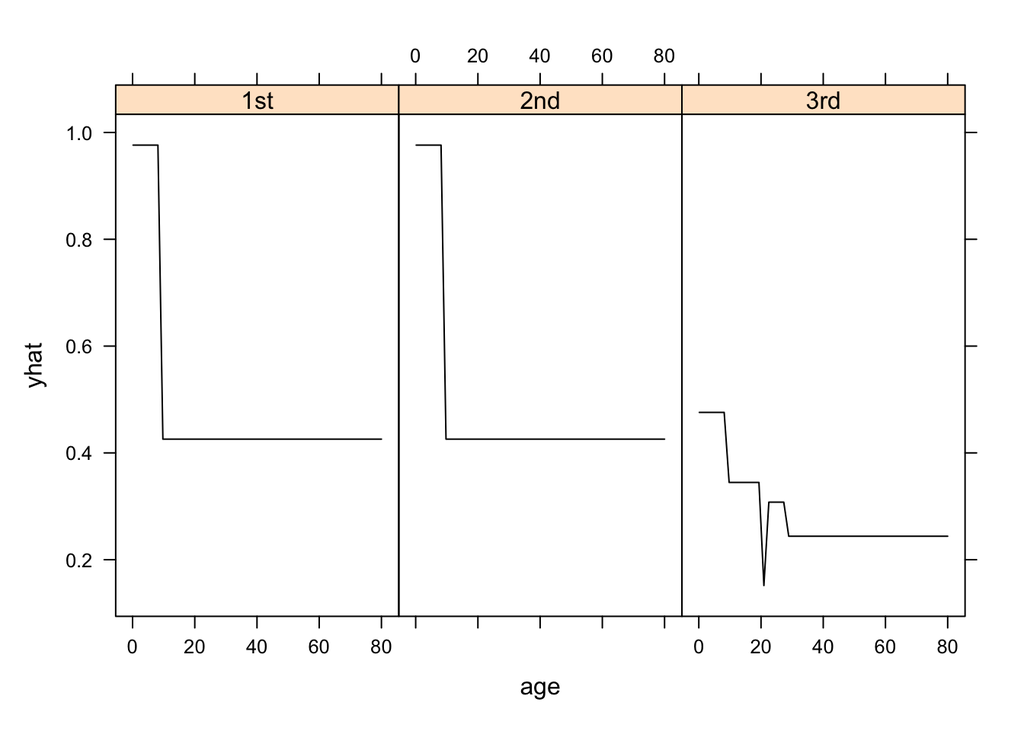

```r
# this is the way to use `map` to do it
# but you can just write the combinations individually

combinations <-
  data.frame(
    combn(
      names(all_var_DT$variable.importance[1:3]),
      m = 2
      )
  )


plt_list <-
  map(
    .x = combinations,
    .f =
      ~partial(
        all_var_DT,
        pred.var = unlist(.x),
        type = 'classification',
        which.class = 'survived',
        plot = TRUE,
        prob = TRUE
      )

  )

plt_list
```

### Section 1.5: Evaluate Model Performance (unseen data)

Use your withheld testing data to determine the percent of new predictions that are correct.

```r
accuracy_percentages <-
  testing_data %>%
  mutate(
    predicted =
      predict(
        all_var_DT,
        newdata = testing_data,
        type = 'class'
        ),
    actual = survived,
    prediction_accuracy =
      if_else(
        actual == predicted,
        'Correct',
        'Incorrect
        ')
  ) %>%
  count(prediction_accuracy) %>%
  mutate(
    percent =
      paste0(
        round(
          (n / sum(n))* 100),
        '%'
        )
  )
```

```r
accuracy_percentages
```

```
##   prediction_accuracy   n percent
## 1             Correct 252     77%
## 2 Incorrect\n          76     23%
```

When done, return your focus to the presentation